# An Analysis of NASDAQ market data in Facebook’s Prophet

### Setup

```r
library(tidyverse)
library(xts)
library(tidyquant)
library(PerformanceAnalytics)
library(PortfolioAnalytics)
library(data.table)
library(prophet)
library(quantmod)
library(lubridate)
library(tidymodels)
```

### Grab data from Yahoo Finance

```r
## Get SP_500 market data from 1975 through today data

# read_csv("Data/^GSPC.csv") # get data via CSV

 getSymbols('QQQ', from = 1999-03-11, to = Sys.Date() + 1,warnings = FALSE,
           auto.assign = TRUE, src = "yahoo")  # read data via getSymbols
```

```
[1] "QQQ"
```

```r
df <- QQQ # rename the df

df <- as.data.frame(df) # convert from xts to df
df$Date <- rownames(df)

rownames(df) <- NULL # reset index column

colnames(df) <-c("Open", "High","Low","Close","Volume","Adjusted","Date") # Modify column names

df <- subset(df, select=-c(High,Low)) # remove 'High' and 'Low' columns from the df
```

[output not shown]

[output cut: 1 more lines]

```r
df %>%
  filter(df$Close/df$Open > 1.07) # times the market closed 5% lower



df %>%
  filter(df$Open/df$Close > 1.07) # times the market has closed 5% higher
```

| Open | Close | Volume | Adjusted | Date |
| --- | --- | --- | --- | --- |
| 86.87500 | 80.09375 | 37134800 | 69.03374 | 2000-01-06 |
| 107.62500 | 100.12500 | 26988200 | 86.29894 | 2000-04-10 |
| 86.06250 | 80.37500 | 60851300 | 69.27614 | 2000-04-14 |
| 81.37500 | 74.81250 | 31898500 | 64.48179 | 2000-05-23 |
| 82.12500 | 75.70312 | 40338200 | 65.24941 | 2000-11-08 |
| 63.45312 | 59.12500 | 80489200 | 50.96055 | 2000-12-19 |
| 58.56250 | 53.43750 | 62514100 | 46.05842 | 2001-01-02 |
| 61.31250 | 56.62500 | 68782000 | 48.80576 | 2001-01-05 |
| 45.20000 | 42.15000 | 74135500 | 36.32959 | 2001-03-15 |
| 43.44000 | 40.35000 | 104796200 | 34.77815 | 2001-03-20 |

[output cut: 5 more lines]

### Forecasting Future Returns

```r
df_Date_N_Close<- df %>%
  select(Date,Close)

names(df_Date_N_Close) <- c("ds","y") # name date and close columns in df_Date_N_Close

prophet(df_Date_N_Close)
```

```
Disabling daily seasonality. Run prophet with daily.seasonality=TRUE to override this.
```

[output not shown]

[output cut: 1508 more lines]

[output not shown]

```r
m2<-prophet(df_Date_N_Close, weekly.seasonality =FALSE)
```

```
Disabling daily seasonality. Run prophet with daily.seasonality=TRUE to override this.
```

```r
future <- make_future_dataframe(m2, periods = 3650) # run for a period of 10 years

#tail(future)

forecast <- predict(m2, future)

#tail(forecast[c('ds', 'yhat', 'yhat_lower', #'yhat_upper')])
```

Here we used the machine learning package “Prophet” to begin to forecast the future of the stock market via additive regression models.

### Plotting Next 10 Years

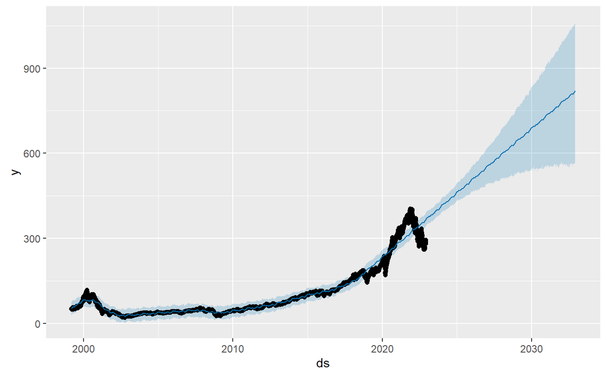

```r
plot(m2, forecast)
```

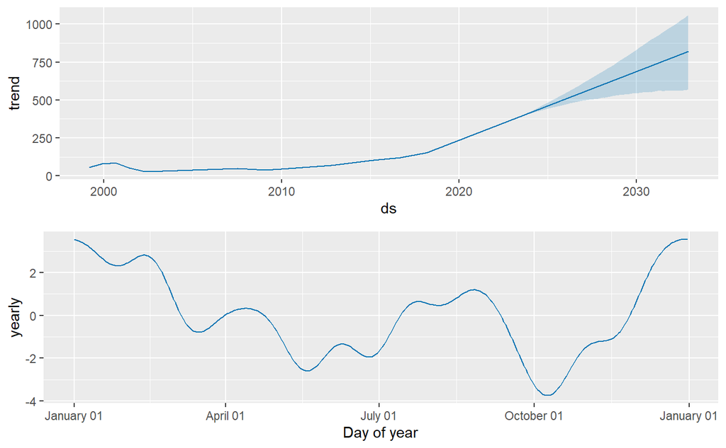

```r
prophet_plot_components(m2, forecast)
```

One can see a large dip in the month of October when the data in aggregate was analyzed. This is in accordance with the “October Effect” which is a perceived market anomaly where stocks dip during the month. It is generally understood that this dip is due to the psychological expectation rather than a legitimate statistical phenomenon (ex. investors may be nervous due to some of histories largest market crashes ever occurring in the month).

```r
#Begin trimming from 1980 to just 2005 - 2025

 df_Date_N_Close_Since_2005<- setDT(df_Date_N_Close)[ds %between% c('2005-01-01', '2025-01-01')]


names(df_Date_N_Close_Since_2005) <- c("ds","y")

prophet(df_Date_N_Close_Since_2005)
```

```
Disabling daily seasonality. Run prophet with daily.seasonality=TRUE to override this.
```

[output not shown]

[output cut: 907 more lines]

[output not shown]

[output not shown]

[output cut: 990 more lines]

[output not shown]

[output cut: 201 more lines]

```r
m3<-prophet(df_Date_N_Close_Since_2005, weekly.seasonality = FALSE)
```

```
Disabling daily seasonality. Run prophet with daily.seasonality=TRUE to override this.
```

```r
future <- make_future_dataframe(m3, periods = 1825) # 5 year view
# tail(future)

forecast <- predict(m3, future)
# tail(forecast[c('ds', 'yhat', 'yhat_lower', 'yhat_upper')])
```

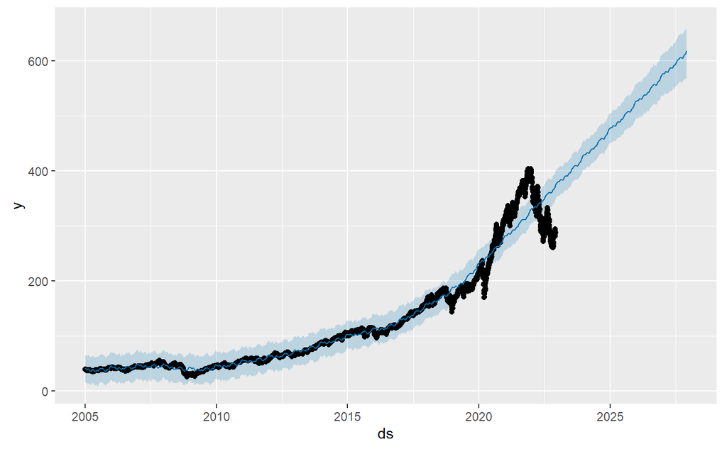

```r
plot(m3, forecast)
```

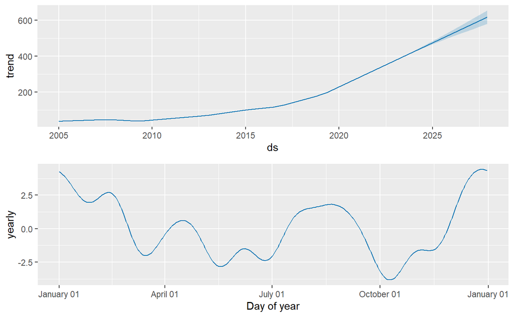

```r
prophet_plot_components(m3, forecast)
```

```r
#Begin trimming from 1980 to just March 2018 - March 2020



 df_Date_N_Close_Since_2005<- setDT(df_Date_N_Close)[ds %between% c('2018-03-01', '2023-03-01')]




names(df_Date_N_Close_Since_2005) <- c("ds","y")

prophet(df_Date_N_Close_Since_2005)
```

```
Disabling daily seasonality. Run prophet with daily.seasonality=TRUE to override this.
```

[output not shown]

[output cut: 468 more lines]

[output not shown]

[output not shown]

[output cut: 990 more lines]

[output not shown]

[output cut: 201 more lines]

```r
m4<-prophet(df_Date_N_Close_Since_2005, weekly.seasonality = FALSE)
```

```
Disabling daily seasonality. Run prophet with daily.seasonality=TRUE to override this.
```

```r
future <- make_future_dataframe(m4, periods = 365) # 1 year prediction
# tail(future)

forecast <- predict(m4, future)
# tail(forecast[c('ds', 'yhat', 'yhat_lower', 'yhat_upper')])
```

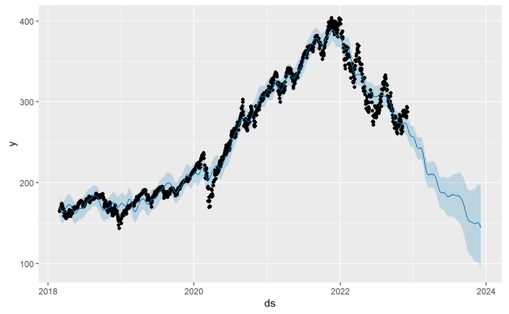

```r
plot(m4, forecast)
```

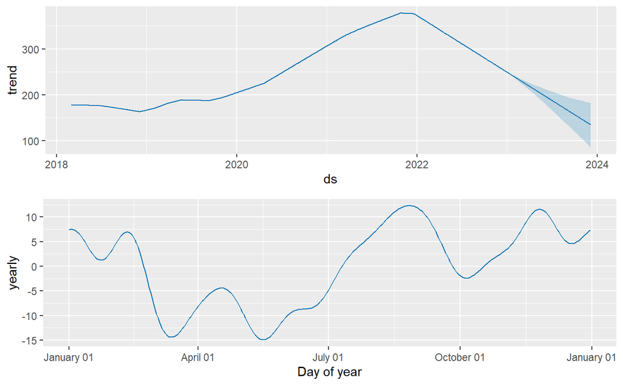

```r
 prophet_plot_components(m4, forecast)
```

Works Cited:

Hayes, A. (n.d.). October Effect Definition. Retrieved May 13, 2019, from Investopedia website: https://www.investopedia.com/terms/o/octobereffect.asp

how to forecast the ‘yhat_upper’ and ‘yhat_lower’ in Prophet? · Issue #637 · facebook/prophet. (n.d.). Retrieved May 13, 2019, from GitHub website: https://github.com/facebook/prophet/issues/637

Prophet: forecasting at scale. (2017, February 23). Retrieved May 13, 2019, from Facebook Research website: https://research.fb.com/prophet-forecasting-at-scale/

Quick Start. (n.d.). Retrieved May 13, 2019, from Prophet website: http://facebook.github.io/prophet/docs/quick_start.html R: How to filter/subset a sequence of dates. (n.d.). Retrieved May 13, 2019, from Stack Overflow website: https://stackoverflow.com/questions/28335715/r-how-to-filter-subset-a-sequence-of-dates

Tool for producing high quality forecasts for time series data that has multiple seasonality with linear or non-linear growth.: facebook/prophet [Python]. (2019). Retrieved from https://github.com/facebook/prophet (Original work published 2016)